# Análise Exploratória de Dados

Análise de Dados I - 2018.1

## Exploratory Data Analysis (EDA)

## O que é EDA?

- Sumarização e visualização de dados para analisar suas características principais
- Ciclo iterativo:
  - Faça perguntas sobre os dados.
  - Procure respostas visualizando, transformando e modelando os dados.
  - Use o que aprendeu para refinar perguntas e/ou fazer novas perguntas.
- Inicialmente, investigue qualquer ideia que surgir
  - Algumas darão certo, outras não.

## *“Far better an approximate answer to the right question, which is often vague, than an exact answer to the wrong question, which can always be made precise.”* — John Tukey

## Fazendo perguntas

- Seu objetivo na EDA é desenvolver um entendimento dos dados
  - A forma mais fácil é fazendo perguntas para guiar sua investigação
  - Foca sua atenção em partes específicas dos dados
  - Ajuda a decidir que gráficos, modelos ou transformações fazer
- É um processo criativo
  - A chave para fazer perguntas de **qualidade** é produzir uma grande **quantidade** de perguntas
  - Como fazer perguntas reveladoras sem conhecer os dados?
- Cada pergunta expõe um novo aspecto dos dados
  - Aumenta a chance de novas descobertas
  - Leva a insights interessantes deixando as perguntas levarem a outras

## Tipos de perguntas

Não há regras, mas dois tipos são muito úteis para novas descobertas:

- Que tipo de **variação** ocorre nas minhas variáveis?
- Que tipo de **covariação** ocorre entre as minhas variáveis?

Algumas definições:

- **Variável**: quantidade, qualidade ou propriedade que você pode medir.
- **Valor**: estado de uma variável quando você a mede (pode mudar).
- **Observação**: conjunto de medições feitas em condições similares.

## Variância

## O que é *variância* e por que analisá-la?

- Tendência de uma variável mudar seu valor de uma medição para outra
- Cada variável tem seu próprio padrão de variação
  - Pode revelar informações interessantes
- A melhor forma de entender padrões é visualizando a distribuição dos dados
- Como visualizar distribuições?
  - Depende se dados são *categóricos* ou *contínuos*

## Visualizando dados categóricos

- Uma variável categórica só pode assumir um pequeno conjunto de valores

Podemos examinar a distribuição de dados categóricos:

- Usando um gráfico de barras:

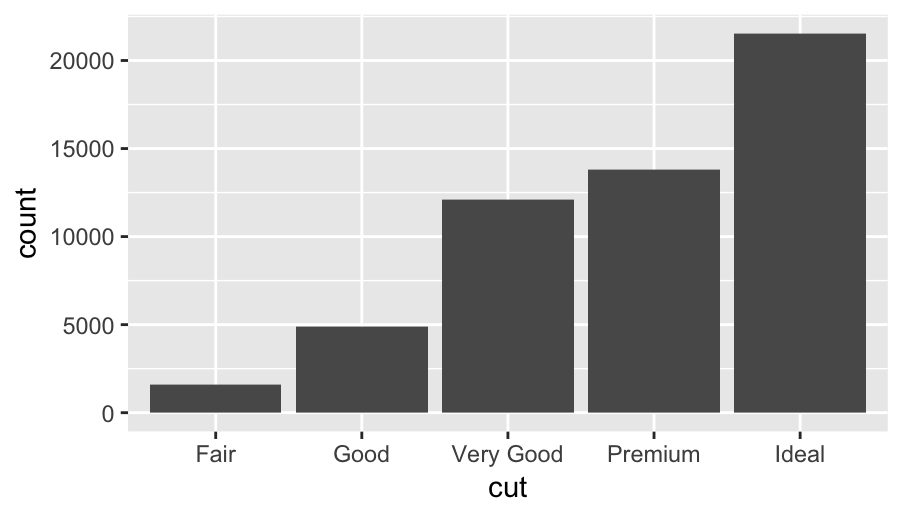

```r
ggplot(diamonds, aes(x = cut)) +
  geom_bar()
```

- Ou computando manualmente:

```r
diamonds %>%
  count(cut)
```

```
## # A tibble: 5 x 2
##   cut           n
##   <ord>     <int>
## 1 Fair       1610
## 2 Good       4906
## 3 Very Good 12082
## 4 Premium   13791
## 5 Ideal     21551
```

## Visualizando dados contínuos

Uma variável contínua pode assumir qualquer valor entre um conjunto infinito de valores ordenados (Exemplo: números e datas)

- Podemos visualizar com *histograma*:

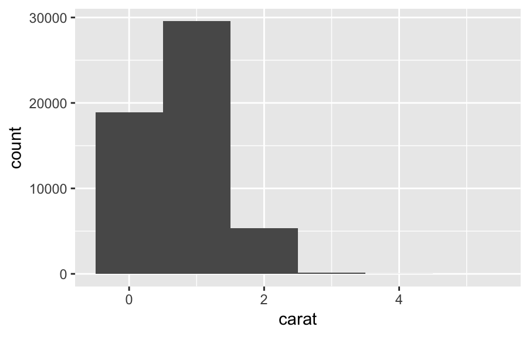

```r
ggplot(diamonds, aes(x = carat)) +
  geom_histogram(binwidth = 1)
```

- Ou computando manualmente:

```r
diamonds %>%
  count(cut_width(carat, 1))
```

```
## # A tibble: 6 x 2
##   `cut_width(carat, 1)`     n
##   <fct>                 <int>
## 1 [-0.5,0.5]            18932
## 2 (0.5,1.5]             29566
## 3 (1.5,2.5]              5316
## 4 (2.5,3.5]               117
## 5 (3.5,4.5]                 8
## 6 (4.5,5.5]                 1
```

## Visualizando dados contínuos - Histogramas

- O *binwidth* define a largura dos intervalos de um histograma
  - Exemplo para diamantes com menos de 3 quilates e intervalos menores:

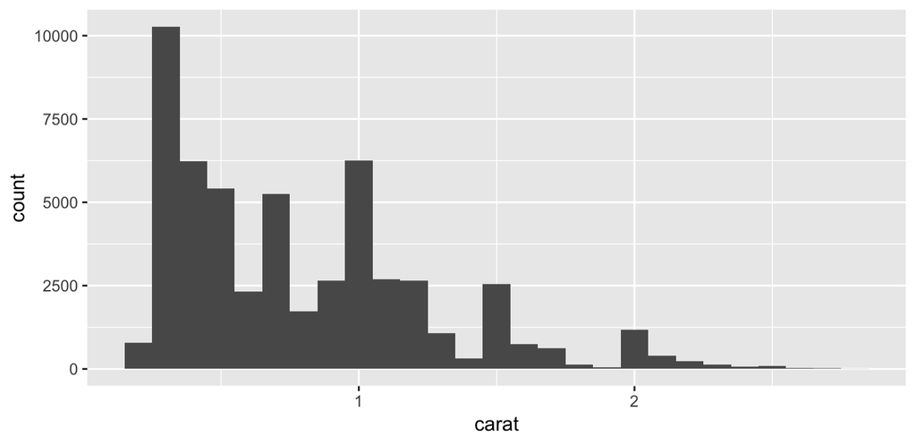

```r
smaller <- diamonds %>%
  filter(carat < 3)
ggplot(smaller, aes(x = carat)) + geom_histogram(binwidth = 0.1)
```

## Visualizando dados contínuos - Histogramas

- Para vários histogramas no mesmo gráfico, recomenda-se `geom_freqpoly`
  - Plota contagens com um linha pra cada categoria, ao invés de barras

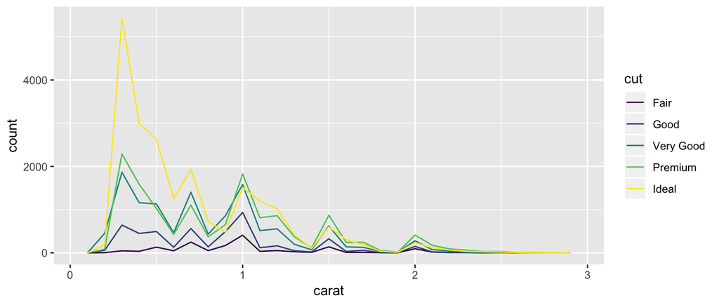

```r
ggplot(smaller, aes(x = carat, colour = cut)) +
  geom_freqpoly(binwidth = 0.1)
```

## Já visualizamos variação… e agora? Que outras perguntas faremos?

## Valores típicos

- Gráfico de barras e histogramas mostram valores mais e menos frequentes
- Para tornar essa informação em algo útil, procure algo inesperado:
  - Quais valores são mais comuns? Por que?
  - Quais valores são raros? Isso corresponde às expectativas?
  - Você consegue ver padrões incomuns? O que pode explicá-los?

## Valores típicos - perguntas interessantes

- Por que tem mais diamantes com quilates inteiros e algumas frações comuns?
- Por que tem mais diamantes à direita de cada pico do que à esquerda?
- Por que não há diamantes com mais que 3 quilates?

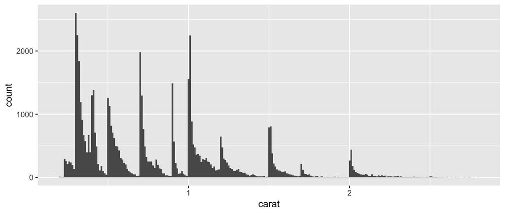

```r
ggplot(smaller, aes(x = carat)) + geom_histogram(binwidth = 0.01)
```

## Agrupamento de valores similares - Perguntas

- Quão parecidas são as observações dentro de cada grupo?
- Quão diferentes são as observações de grupos diferentes?
- Como você pode explicar ou descrever os grupos?

**Exemplo**: duração de erupções do *Old Faithful Geyser*, em minutos

Aparenta divisão em dois grupos:

- Erupções curtas (\(\approx 2\) minutos)
- Erupções longas (\(4 - 5\) minutos)

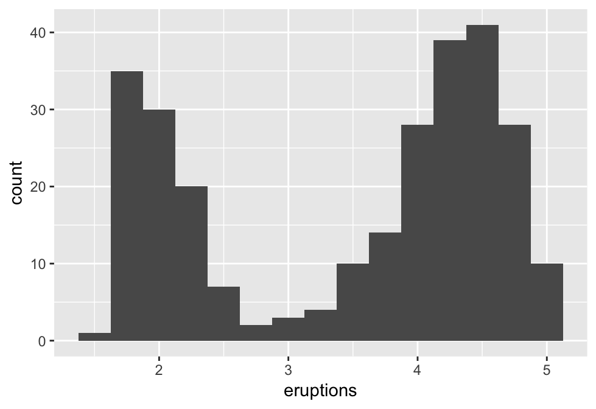

```r
ggplot(faithful, aes(x = eruptions)) +
  geom_histogram(binwidth = 0.25)
```

## Valores incomuns - *outliers*

Dados que não aparentam seguir o padrão.

- Pode ser erro nos dados, mas pode ser algo importante porém inesperado

Ex: altura de diamantes. Outliers?

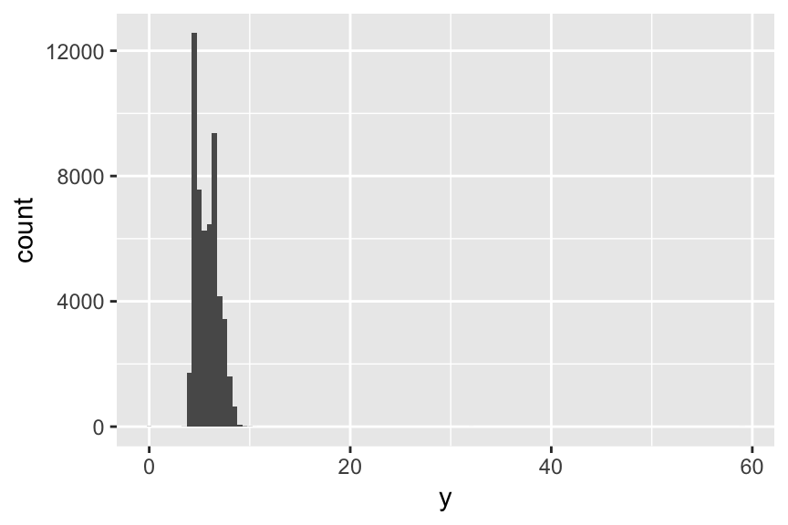

```r
ggplot(diamonds, aes(x = y)) +
  geom_histogram(binwidth = 0.5)
```

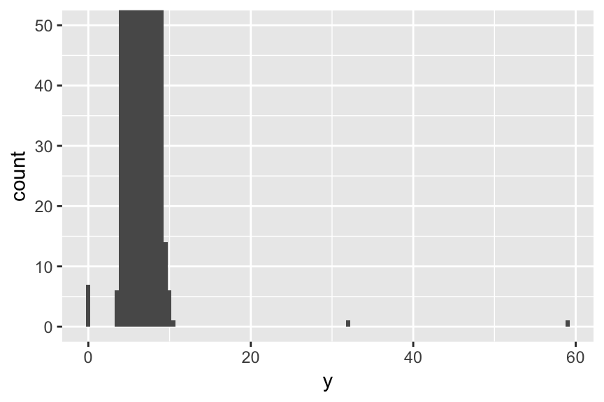

```r
# Com zoom
ggplot(diamonds, aes(x = y)) +
  geom_histogram(binwidth = 0.5) +
  coord_cartesian(ylim = c(0, 50))
```

## Investigando valores incomuns: 0, ~30 e ~60

```r
diamonds %>%
  filter(y < 3 | y > 20) %>%
  select(price, x, y, z) %>%
  arrange(y)
```

```
## # A tibble: 9 x 4
##   price     x     y     z
##   <int> <dbl> <dbl> <dbl>
## 1  5139  0      0    0
## 2  6381  0      0    0
## 3 12800  0      0    0
## 4 15686  0      0    0
## 5 18034  0      0    0
## 6  2130  0      0    0
## 7  2130  0      0    0
## 8  2075  5.15  31.8  5.12
## 9 12210  8.09  58.9  8.06
```

**Faz sentido (?)**

- Diamantes com dimensões (x, y e z) iguais a zero?
- Diamantes com dimensões muito grandes, mas que não custam tão caro?

## O que fazer com valores estranhos?

- **Opção 1**: Eliminar as linhas (observações) que têm valores estranhos
  - Mas, se 1 medição é estranha as outras na mesma linha podem não ser

```r
diamonds_filtered <- diamonds %>%
  filter(between(y, 3, 20))
```

- **Opção 2**: Substituir valores estranhos por valores inexistentes
  - Representado por `NA` no R (*Not Available*). Não afeta estatísticas.

```r
diamonds_na <- diamonds %>%
  mutate(y = ifelse(y < 3 | y > 20, NA, y))
```

## Ex: antes e depois de substituir *outliers* por `NA`

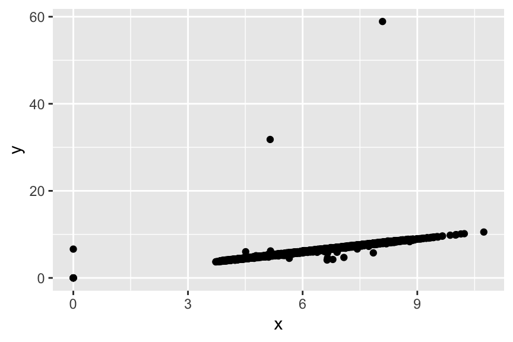

```r
ggplot(diamonds, aes(x, y)) +
  geom_point()
```

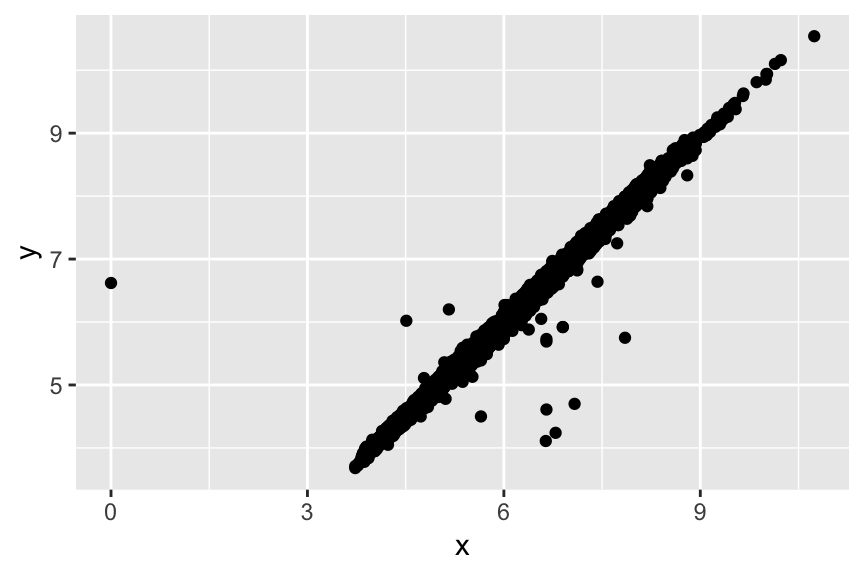

```r
ggplot(diamonds_na, aes(x, y)) +
  geom_point()
```

## Covariância

## O que é covariância e por que analisá-la?

- *Covariância* descreve o comportamento **entre variáveis**.
  - Tendência de 2 ou mais variáveis variarem juntas, de forma relacionada.
- É importante para encontrar padrões de relacionamento entre variáveis
  - E criar modelos que estimam valores com base nessas relações
  - Ex: estimar votos de candidatos com base nos gastos de campanha
- A melhor forma de identificar covariância é visualizar o relacionamento entre variáveis
  - Novamente, isto depende dos tipos das variáveis

## Covariância: 1 variável categórica e 1 contínua

- Problema: categorias com frequências muito diferentes
  - Solução 1: plotar valor normalizado por categoria (densidade)

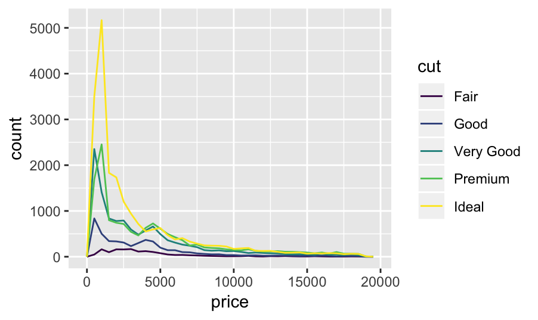

```r
diamonds %>%
 ggplot(aes(price, col = cut)) +
 geom_freqpoly(binwidth = 500)
```

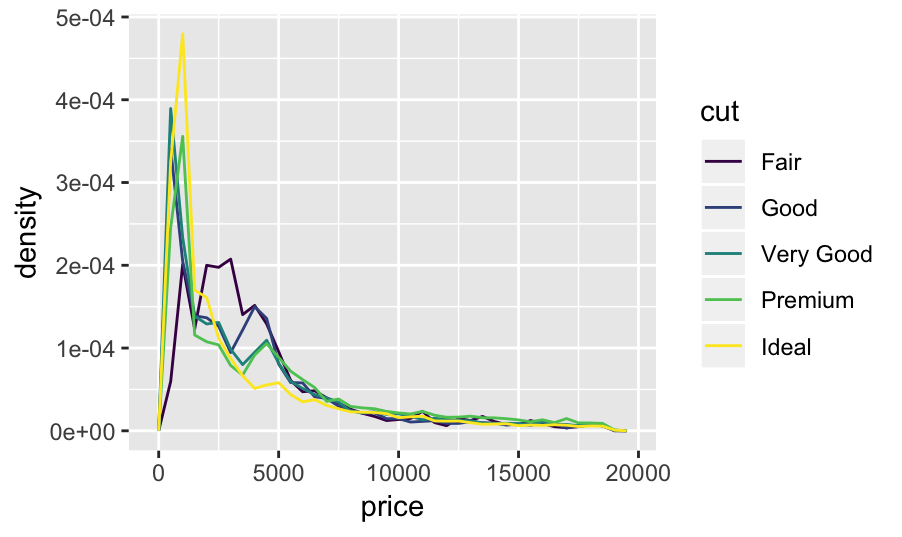

```r
diamonds %>%
 ggplot(aes(price, stat(density), col = cut)) +
 geom_freqpoly(binwidth = 500)
```

## Alternativa para comparar variâncias: *Boxplot*

- Mostra visualmente algumas estatísticas populares de uma distribuição

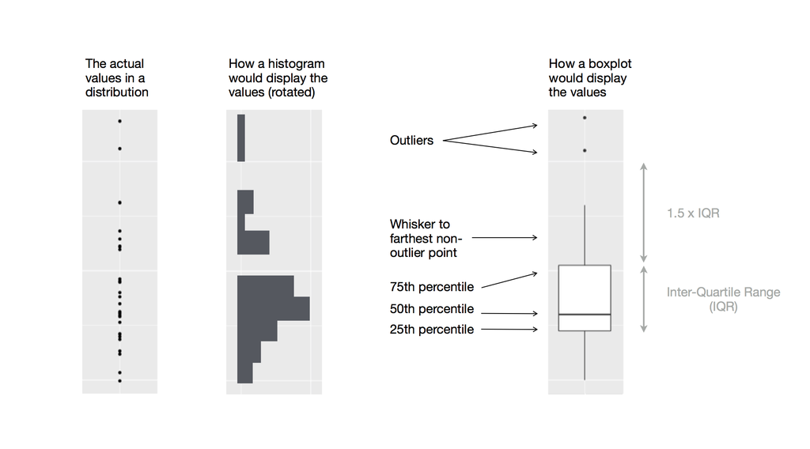

## Covariância: 1 variável categórica e 1 contínua

- Solução 2: boxplot para comparar variâncias por categoria
  - Mais compacto, mais fácil de comparar várias categorias

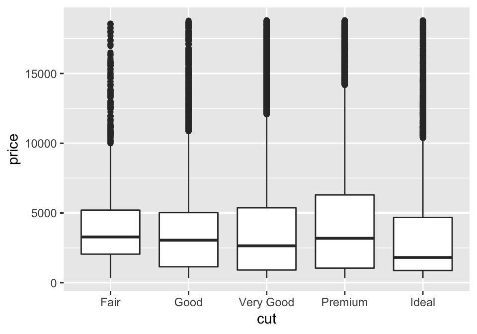

```r
ggplot(diamonds, aes(cut, price)) +
  geom_boxplot()
```

- Diamantes de maior qualidade são mais baratos? Por que?!

## Variáveis categóricas

- A qualidade dos diamantes é uma variável categórica **ordinal**
  - Há uma ordem da menor qualidade (*Fair*) para a maior qualidade (*Ideal*)
- Variáveis categóricas podem ser **não ordinais** se não há ordem nos valores
  - Neste caso, podemos ordená-las de acordo com outras variáveis

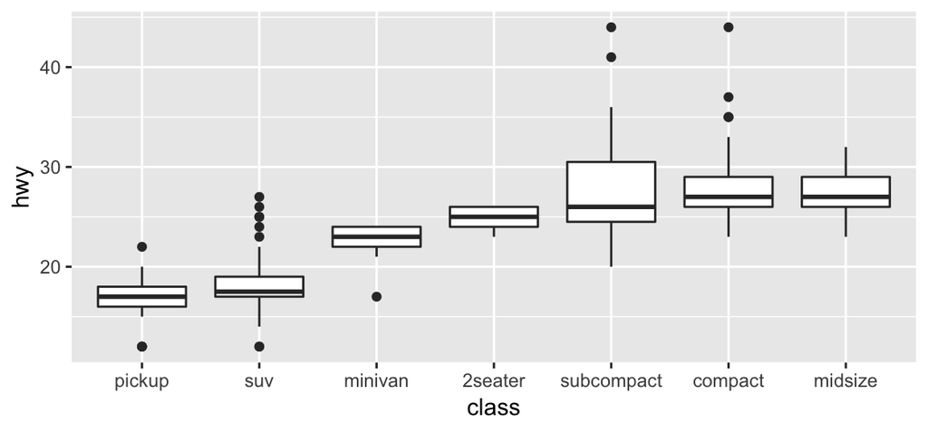

```r
ggplot(mpg, aes(x = reorder(class, hwy, FUN = median), y = hwy)) +
  geom_boxplot() + xlab("class")
```

## Covariância: duas variáveis categóricas

- Contar a quantidade de observações para cada combinação

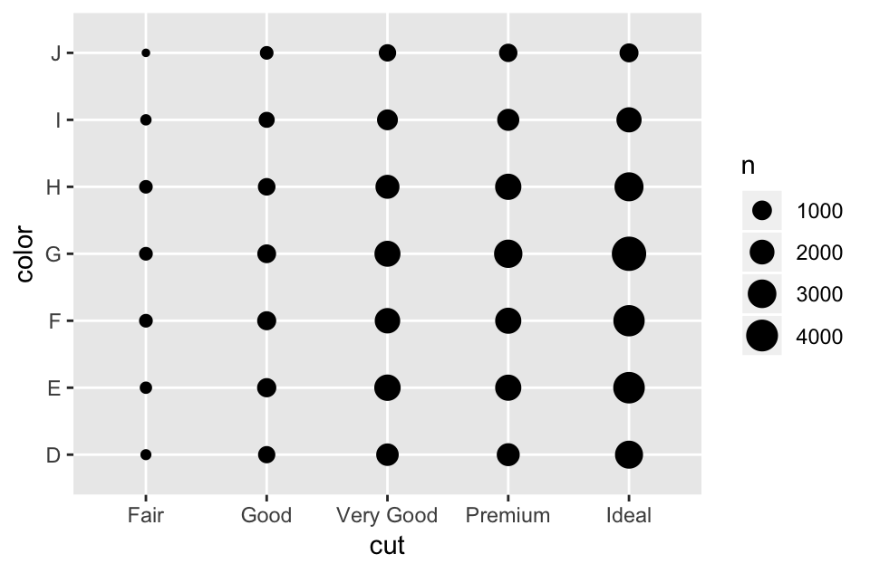

```r
diamonds %>%
  ggplot(aes(cut, color)) +
  geom_count()
```

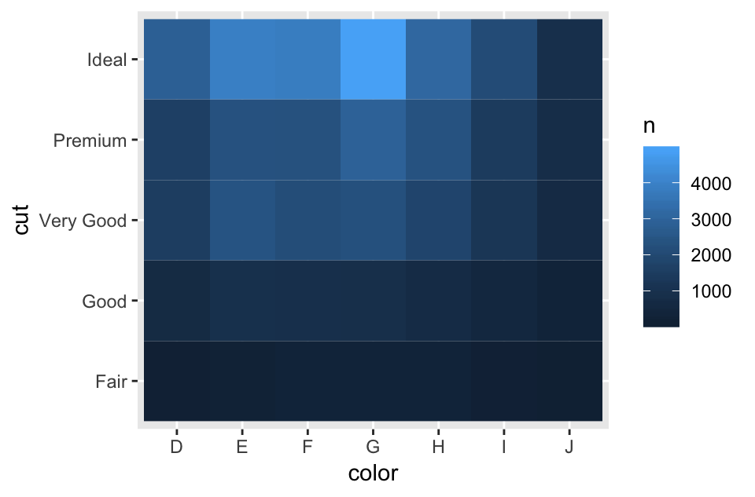

```r
count(diamonds, color, cut) %>%
  ggplot(mapping = aes(color, cut)) +
    geom_tile(aes(fill = n))
```

## Covariância: duas variáveis contínuas

- Já vimos uma opção: scatter plots

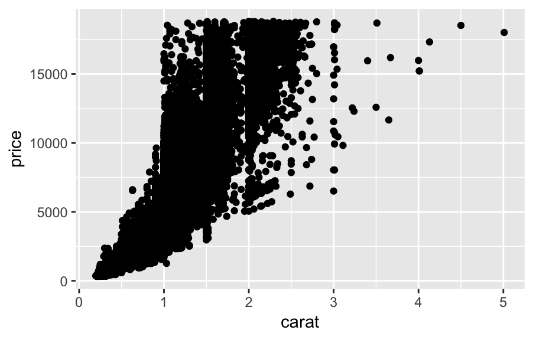

```r
ggplot(diamonds, aes(carat, price)) +
  geom_point()
```

- Com transparência (`alpha`)

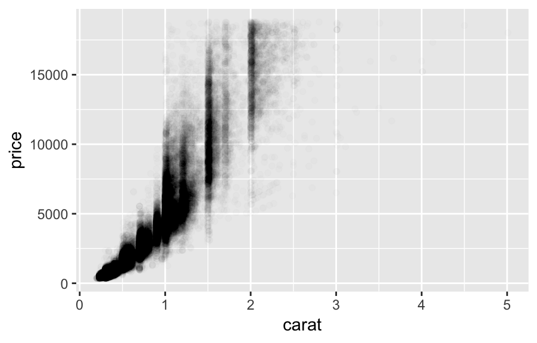

```r
ggplot(diamonds, aes(carat, price)) +
  geom_point(alpha = 1 / 100)
```

## Covariância: duas variáveis contínuas

- Opção 2: *bin* (como `geom_histogram`, mas para 2 dimensões)

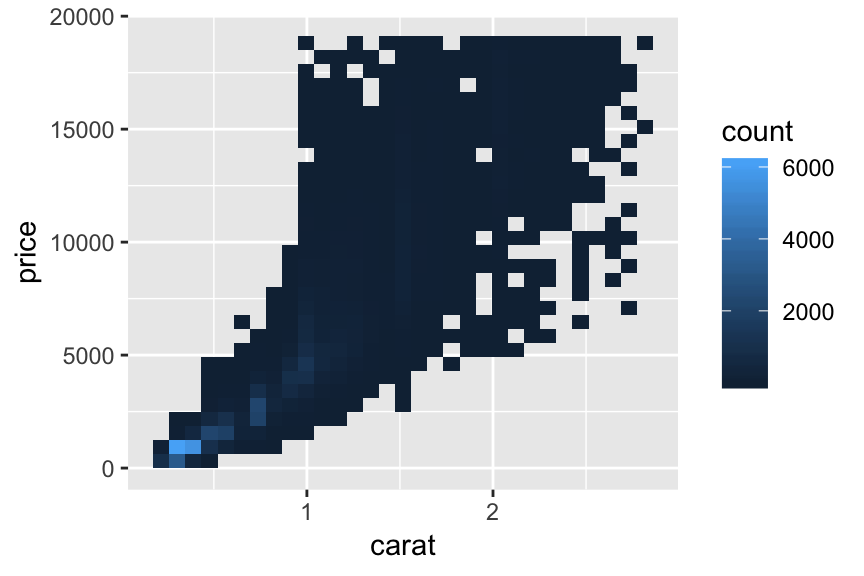

```r
ggplot(smaller) +
  geom_bin2d(aes(carat, price))
```

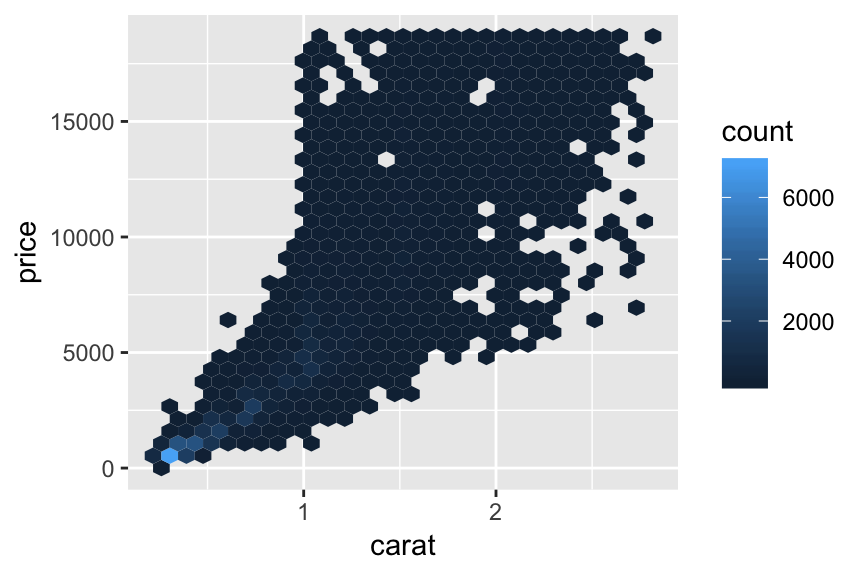

```r
ggplot(smaller) +
  geom_hex(aes(carat, price))
```

## Covariância: duas variáveis contínuas

- Opção 3: tratar uma das variáveis como categóricas

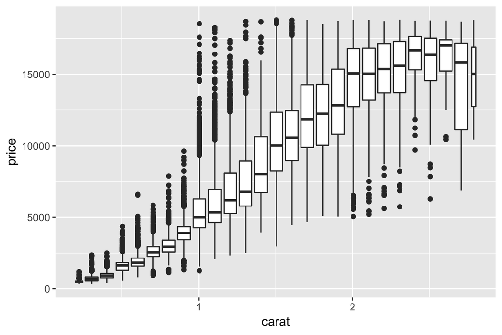

```r
ggplot(smaller, aes(carat, price)) +
  geom_boxplot(aes(group = cut_width(carat, 0.1)))
```

## Covariância: 2 variáveis contínuas e 1 categórica

- Para comparar relações para diferentes categorias: subplots (ou *facets*)

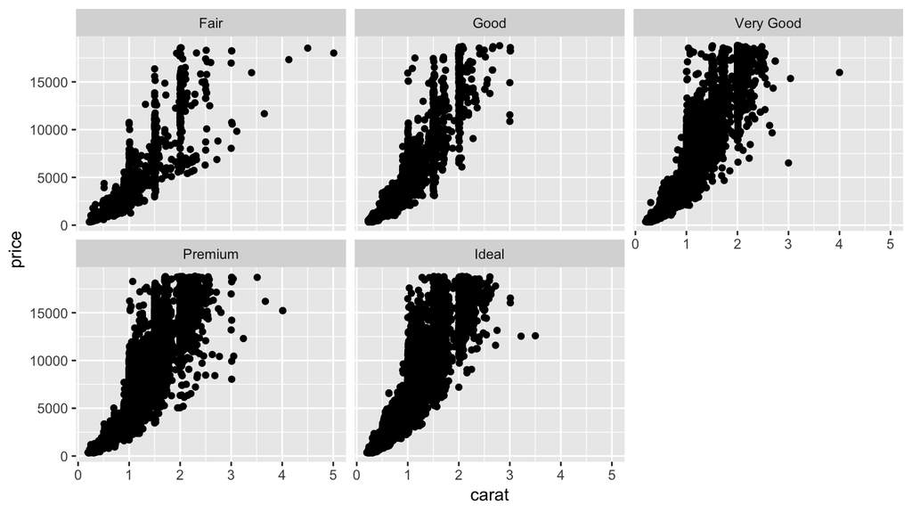

```r
ggplot(diamonds, aes(carat, price)) + geom_point() + facet_wrap(vars(cut))
```

## Covariância: 2 variáveis contínuas e 2 categóricas

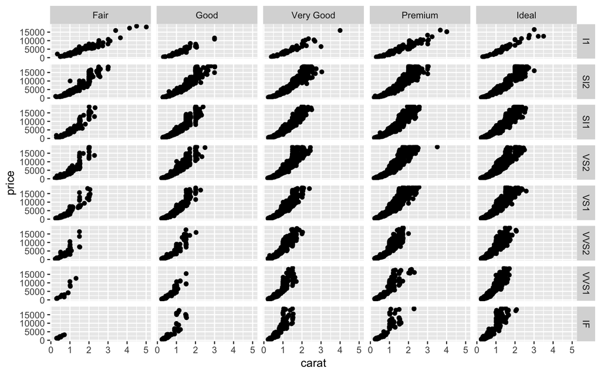

```r
ggplot(diamonds, aes(carat, price)) + geom_point() + facet_grid(clarity ~ cut)
```

## Padrões nos dados

Se encontrar padrões, pergunte-se:

- Este padrão acontece por coincidência?
- Como você descreve o relaciomento implicado pelo padrão?
- Quão forte é o relacionado implicado pelo padrão?
- Que outras variáveis afetam este relacionamento?
- O relacionamento muda se você olhar subgrupos individuais dos dados?

## Padrões nos dados

- Exemplo: tempos de espera mais longos geram erupções mais longas

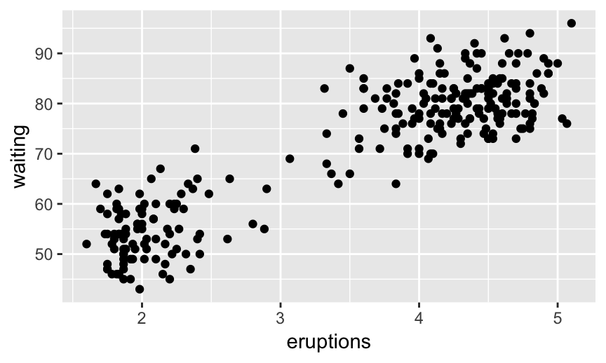

```r
ggplot(faithful, aes(eruptions, waiting)) + geom_point()
```

- **Variância**: gera incerteza; **Covariância**: reduz incerteza.
  - Valores de uma variável podem ajudar a prever valores de outra

## Referências

- R for Data Science. [7 - Exploratory Data Analysis](http://r4ds.had.co.nz/exploratory-data-analysis.html)
- Ciência de dados com R. [9 - Visualizações de dados (ggplot2)](https://cdr.ibpad.com.br/ggplot2.html)
- [Exploratory Data Analysis with R](https://bookdown.org/rdpeng/exdata/).
- Curso R. [Aula 05 - Gráficos com estilo - ggplot2](http://curso-r.github.io/posts/aula05.html)